# vote1

José C. Pernías

3/22/2021

# Datos

Cargamos el paquete `readxl` para leer hojas de cálculo Excel y el paquete `ggplot2` para realizar gráficos:

```r
library(readxl)
library(ggplot2)
```

Leemos las variables del archivo vote1.xlsx:

```r
vote1 <- read_xlsx("vote1.xlsx")
```

# Regresión inicial

Usamos `expendA` para explicar el porcentaje de votos obtenidos por A:
$$voteA = \beta_0 + \beta_1 expendA + u$$

```r
mod1 <- lm(voteA ~ expendA, data = vote1)
summary(mod1)
```

```
##
## Call:
## lm(formula = voteA ~ expendA, data = vote1)
##
## Residuals:
##     Min      1Q  Median      3Q     Max
## -27.885 -12.422  -3.968  15.873  32.687
##
## Coefficients:
##              Estimate Std. Error t value Pr(>|t|)
## (Intercept) 43.171163   1.755322  24.594  < 2e-16 ***
## expendA      0.023604   0.004196   5.625 7.44e-08 ***
## ---
## Signif. codes:  0 '***' 0.001 '**' 0.01 '*' 0.05 '.' 0.1 ' ' 1
##
## Residual standard error: 15.46 on 171 degrees of freedom
## Multiple R-squared:  0.1561, Adjusted R-squared:  0.1512
## F-statistic: 31.64 on 1 and 171 DF,  p-value: 7.438e-08
```

La estimación del parámetro $\beta_1$ indica que por cada 1000$ adicionales de gasto el porcentaje de votos para el candidato A aumentará en 0.024 puntos porcentuales.

Calculamos los residuos y los valores ajustados de la variable dependiente y los almacenamos en la base de datos:

```r
vote1$yhat <- fitted(mod1)
vote1$uhat <- resid(mod1)

head(vote1)
```

```
## # A tibble: 6 x 9
##   state district democA voteA expendA expendB prtystrA  yhat  uhat
##   <chr>    <dbl>  <dbl> <dbl>   <dbl>   <dbl>    <dbl> <dbl> <dbl>
## 1 AL           7      1    68   328.     8.74       41  50.9 17.1
## 2 AK           1      0    62   626.   402.         60  58.0  4.04
## 3 AZ           2      1    73    99.6    3.07       55  45.5 27.5
## 4 AZ           3      0    69   320.    26.3        64  50.7 18.3
## 5 AR           3      0    75   159.    60.0        66  46.9 28.1
## 6 AR           4      1    69   570.    21.4        46  56.6 12.4
```

# Gastos del rival

Gráfico de los residuos con respecto a la variable explicativa:

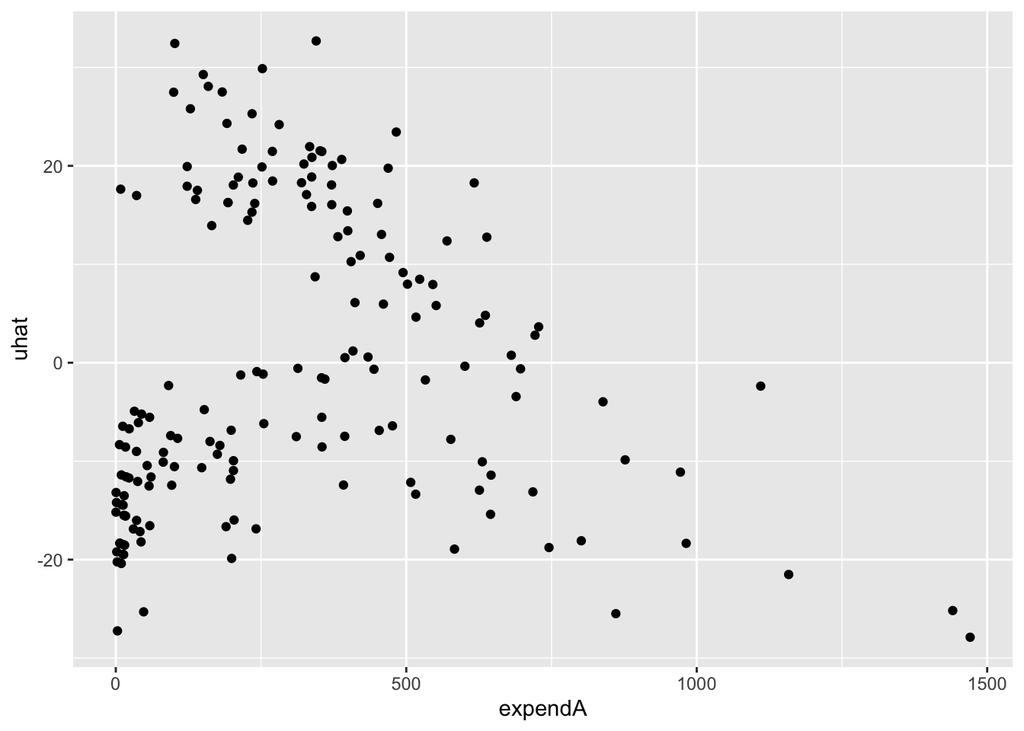

```r
qplot(x = expendA, y = uhat, data = vote1)
```

Gráfico de los residuos con respecto de los gastos del candidato B:

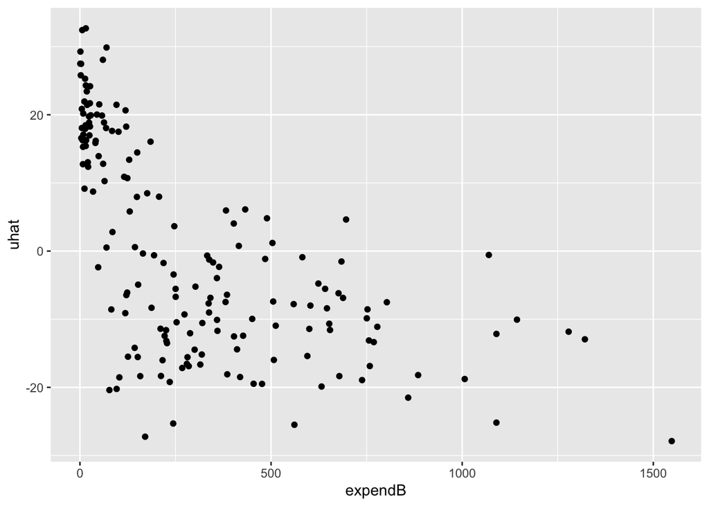

```r
qplot(x = expendB, y = uhat, data = vote1)
```

Correlación entre `expendA` y `expendB`:

```r
with(vote1,  cor(expendA, expendB))
```

```
## [1] 0.3739676
```

Ampliamos el modelo:

```r
mod2 <- update(mod1, . ~ . + expendB)
summary(mod2)
```

```
##
## Call:
## lm(formula = voteA ~ expendA + expendB, data = vote1)
##
## Residuals:
##      Min       1Q   Median       3Q      Max
## -27.5660  -8.6920   0.1639   9.0792  27.0129
##
## Coefficients:
##              Estimate Std. Error t value Pr(>|t|)
## (Intercept) 49.618986   1.426146   34.79   <2e-16 ***
## expendA      0.038331   0.003387   11.32   <2e-16 ***
## expendB     -0.036127   0.003107  -11.63   <2e-16 ***
## ---
## Signif. codes:  0 '***' 0.001 '**' 0.01 '*' 0.05 '.' 0.1 ' ' 1
##
## Residual standard error: 11.58 on 170 degrees of freedom
## Multiple R-squared:  0.5299, Adjusted R-squared:  0.5244
## F-statistic: 95.83 on 2 and 170 DF,  p-value: < 2.2e-16
```

El ajuste ha mejorado mucho, pasando el R$^2$ de 0.1561 a 0.5299.

# Pertenencia al partido demócrata

Finalmente añadimos la variable `democA`:

```r
mod3 <- update(mod2, . ~ . + democA)
summary(mod3)
```

```
##
## Call:
## lm(formula = voteA ~ expendA + expendB + democA, data = vote1)
##
## Residuals:
##      Min       1Q   Median       3Q      Max
## -25.8412  -8.0033  -0.6894   8.7089  27.9815
##
## Coefficients:
##              Estimate Std. Error t value Pr(>|t|)
## (Intercept) 46.773598   1.836019  25.476   <2e-16 ***
## expendA      0.037864   0.003345  11.318   <2e-16 ***
## expendB     -0.034236   0.003163 -10.824   <2e-16 ***
## democA       4.349007   1.803985   2.411    0.017 *
## ---
## Signif. codes:  0 '***' 0.001 '**' 0.01 '*' 0.05 '.' 0.1 ' ' 1
##
## Residual standard error: 11.41 on 169 degrees of freedom
## Multiple R-squared:  0.5456, Adjusted R-squared:  0.5375
## F-statistic: 67.63 on 3 and 169 DF,  p-value: < 2.2e-16
```

El valor de $\hat{\beta}_3$ indica que la afiliación al Partido Demócrata daba una ventaja de algo más de 4 puntos porcentuales, una vez tenidos en cuenta los efectos de los gastos electorales.